# Proj_1_Regression

Marc

6/1/2022

Welcome to my wine project! I hope you will appreciate the journey! For a long time, wine tasters have been seen as the only trustworthy source for giving a reliable opinion on the quality of wine. More recently, Vivino has come into the picture: it relies on community-based ratings. My company “Weeno” (aka We Know) is a newcomer into the field of wine tasting and has to define business problems to make an effective entry into this market. I have defined 2 business goals: one for the short-term and the other for the long-term.

Eventually, when my business expands and my reach increases significantly I will be able to ask users for their ratings and eventually not only display the algorithm’s prediction but also what others think. Now you must be thinking: but isn’t the community part exactly like Vivino’s model, and to that I say “YES”. We are taking customers from Vivino, increasing customer loyalty and then using their own model in an indirect way! However, this is too much of a long-term thinking and not in the scope of this project.

With the scenario being set, in this file you will find the regression problem in which I will proceed in 3 main simple steps: 1. Data cleaning + Data exploration 2. Find the best performing VANILLA model 3. Optimize the best model found in 2.

————————-Step -1: import lbraries ——

–Step 0: import the data

```r
df <- read.csv(file = "WineQuality.csv",
                     header=T,
                     sep=",",
                     dec=".",
                     stringsAsFactors = T)
```

————Step 1: Data exploration + Data cleaning

```r
df %>% map(~ sum(is.na(.)))
```

```
## $fixed.acidity
## [1] 0
##
## $volatile.acidity
## [1] 0
##
## $citric.acid
## [1] 0
##
## $residual.sugar
## [1] 0
##
## $chlorides
## [1] 0
##
## $free.sulfur.dioxide
## [1] 0
##
## $total.sulfur.dioxide
## [1] 0
##
## $density
## [1] 0
##
## $pH
## [1] 0
##
## $sulphates
## [1] 0
##
## $alcohol
## [1] 0
##
## $quality
## [1] 0
```

```r
#Wonderful, no null values
```

Understanding the variables: 1)Residual sugar: the amount of sugar left after the fermentation stops 2)pH: The level of acidity 3)Free sulfur dioxide: prevents microbial growth and the oxidation of wine 4)Fixed acidity: non-volatile acids that do not evaporate immediately 5)Density: the sweeter the wine, the higher density 6)Chlorides: the amount of salt in the wine 7)Alcohol: we all know what it is… 8)Volatile acidity: leads to unpleasant vinegar taste 9)Sulphates: a wine additive that contributes to SO2 levels 10)Total sulfur dioxide: Amount of free + bound forms of SO2 11)Citric acid: acts as preservative to increase acidity

Before starting our exploration phase, allow me to remove some blatant outliers. This step might be unnecessary in your eyes because we are compromising a significant number of data observations. However, these observations largely interfere with the reality of the situation and the results will not be satisfactory. I have tried to do the experiment multiple times, fitting the algorithms to this dataset (once without the outliers and another time as it is), and there was a significant improvement in performance (on test) when I had removed the outliers.

```r
#For outlier cleaning, I have used Cook's distance as a metric as it allows me to get rid of data points with a significant leverage.
table(df$quality)
```

```
##
##    3    4    5    6    7    8    9
##   20  163 1457 2198  880  175    5
```

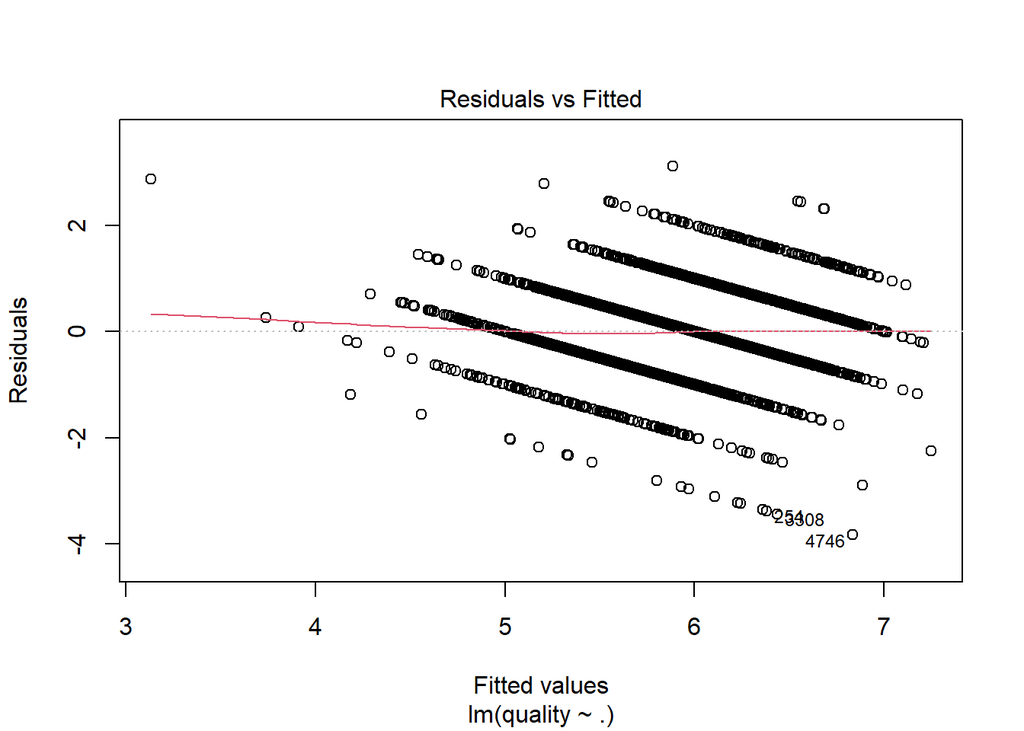

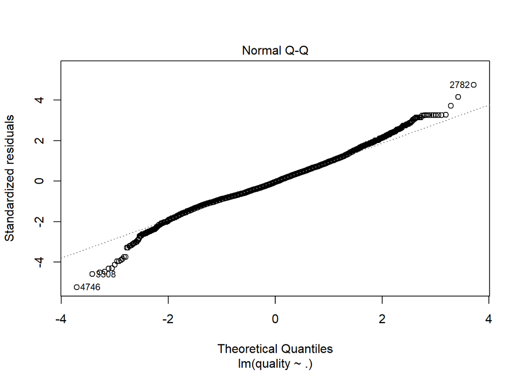

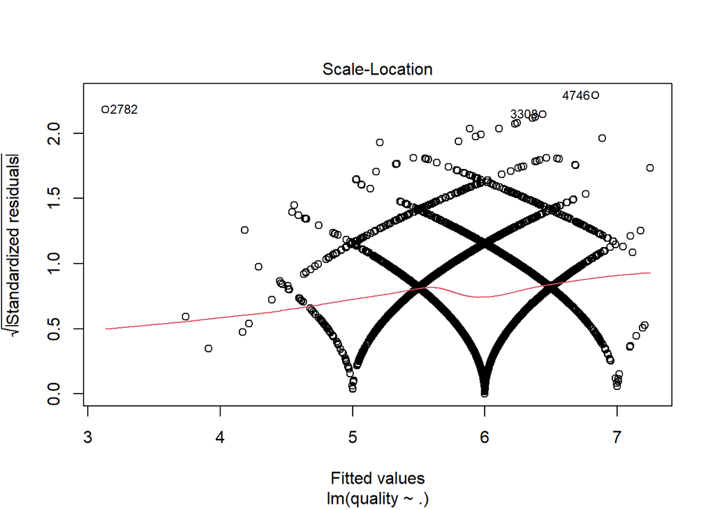

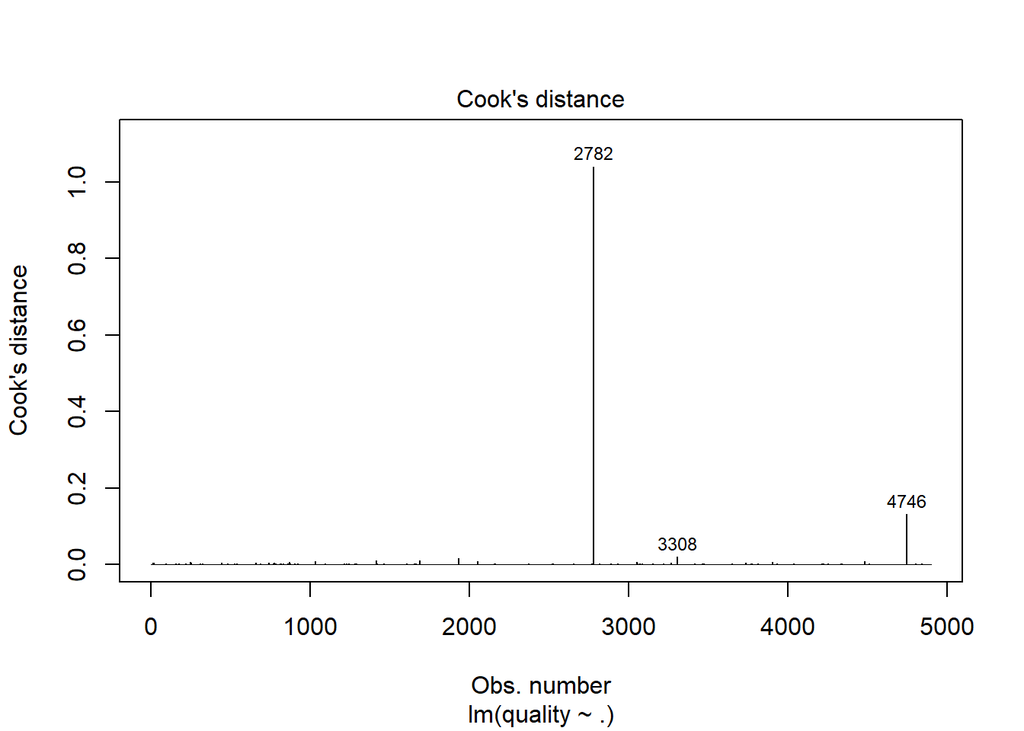

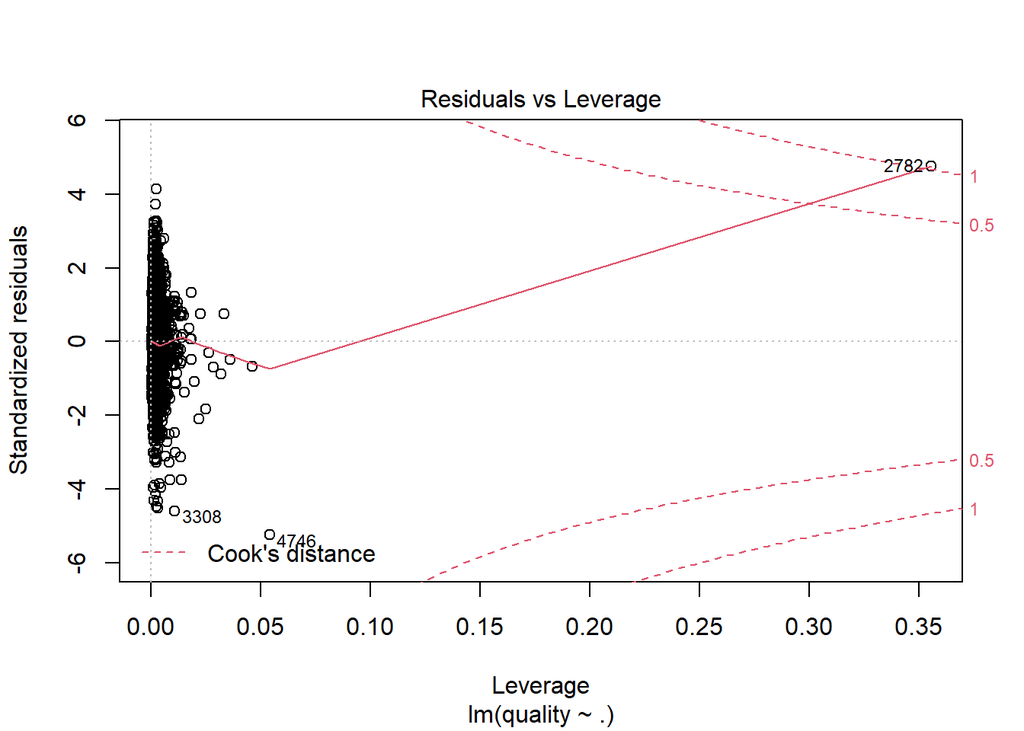

```r
# Get rid of outliers
outliers = c()
for ( i in 1:11 ) {
  stats = boxplot.stats(df[[i]])$stats
  bottom_outlier_rows = which(df[[i]] < stats[1])
  top_outlier_rows = which(df[[i]] > stats[5])
  outliers = c(outliers , top_outlier_rows[ !top_outlier_rows %in% outliers ] )
  outliers = c(outliers , bottom_outlier_rows[ !bottom_outlier_rows %in% outliers ] )
}

#Detect/Remove outliers
mod = lm(quality ~ ., data = df)
cooksd = cooks.distance(mod)
lapply(1:6, function(x) plot(mod, which=x, labels.id= 1:nrow(df))) %>% invisible()
```

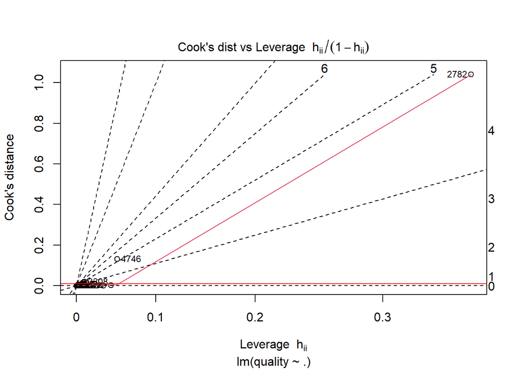

```r
#these graphs show what I have been talking about earlier regardin the high
#leverage that some data points have
abline(h = 20*mean(cooksd, na.rm = T), col = "red")
```

```r
head(df[cooksd > 20 * mean(cooksd, na.rm=T), ])
```

```
##      fixed.acidity volatile.acidity citric.acid residual.sugar chlorides
## 1418           8.6            0.550        0.35          15.55     0.057
## 1689           6.7            0.250        0.26           1.55     0.041
## 1932           7.1            0.490        0.22           2.00     0.047
## 2782           7.8            0.965        0.60          65.80     0.074
## 3308           9.4            0.240        0.29           8.50     0.037
## 4746           6.1            0.260        0.25           2.90     0.047
##      free.sulfur.dioxide total.sulfur.dioxide density   pH sulphates alcohol
## 1418                35.5                366.5 1.00010 3.04      0.63    11.0
## 1689               118.5                216.0 0.99490 3.55      0.63     9.4
## 1932               146.5                307.5 0.99240 3.24      0.37    11.0
## 2782                 8.0                160.0 1.03898 3.39      0.69    11.7
## 3308               124.0                208.0 0.99395 2.90      0.38    11.0
## 4746               289.0                440.0 0.99314 3.44      0.64    10.5
##      quality
## 1418       3
## 1689       3
## 1932       3
## 2782       6
## 3308       3
## 4746       3
```

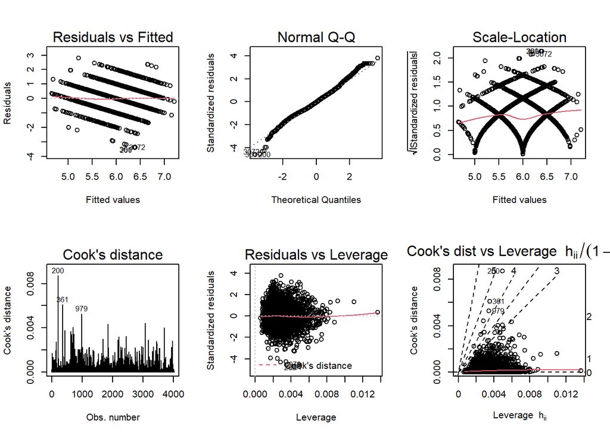

```r
coutliers = as.numeric(rownames(df[cooksd > 20 * mean(cooksd, na.rm=T), ]))
outliers = c(outliers , coutliers[ !coutliers %in% outliers ] )
df = df[-outliers, ]
mod = lm(quality ~ ., data = df)
par(mfrow=c(2,3))
lapply(1:6, function(x) plot(mod, which=x, labels.id= 1:nrow(df))) %>% invisible()
```

```r
#much better results after the omission of the outliers
```

```r
range(df$quality)
```

```
## [1] 3 9
```

values in population generally range on a scale from 0 to 10 but in our dataset minimum is 3 and max is 9, so no exceptional or horrible wine.

```r
table(df$quality)
```

```
##
##    3    4    5    6    7    8    9
##    8   89 1106 1866  797  145    4
```

Very few have a quality of 9 and 3. Let’s see a histogram of quality

```r
str(df)
```

```
## 'data.frame':    4015 obs. of  12 variables:
##  $ fixed.acidity       : num  7 6.3 8.1 7.2 7.2 8.1 6.2 7 6.3 8.1 ...
##  $ volatile.acidity    : num  0.27 0.3 0.28 0.23 0.23 0.28 0.32 0.27 0.3 0.22 ...
##  $ citric.acid         : num  0.36 0.34 0.4 0.32 0.32 0.4 0.16 0.36 0.34 0.43 ...
##  $ residual.sugar      : num  20.7 1.6 6.9 8.5 8.5 6.9 7 20.7 1.6 1.5 ...
##  $ chlorides           : num  0.045 0.049 0.05 0.058 0.058 0.05 0.045 0.045 0.049 0.044 ...
##  $ free.sulfur.dioxide : num  45 14 30 47 47 30 30 45 14 28 ...
##  $ total.sulfur.dioxide: num  170 132 97 186 186 97 136 170 132 129 ...
##  $ density             : num  1.001 0.994 0.995 0.996 0.996 ...
##  $ pH                  : num  3 3.3 3.26 3.19 3.19 3.26 3.18 3 3.3 3.22 ...
##  $ sulphates           : num  0.45 0.49 0.44 0.4 0.4 0.44 0.47 0.45 0.49 0.45 ...
##  $ alcohol             : num  8.8 9.5 10.1 9.9 9.9 10.1 9.6 8.8 9.5 11 ...
##  $ quality             : int  6 6 6 6 6 6 6 6 6 6 ...
```

Only numerical variables, all continuous except for quality (which is the target variable)

This makes our life easier in the univariate EDA, as we only have to draw histograms!

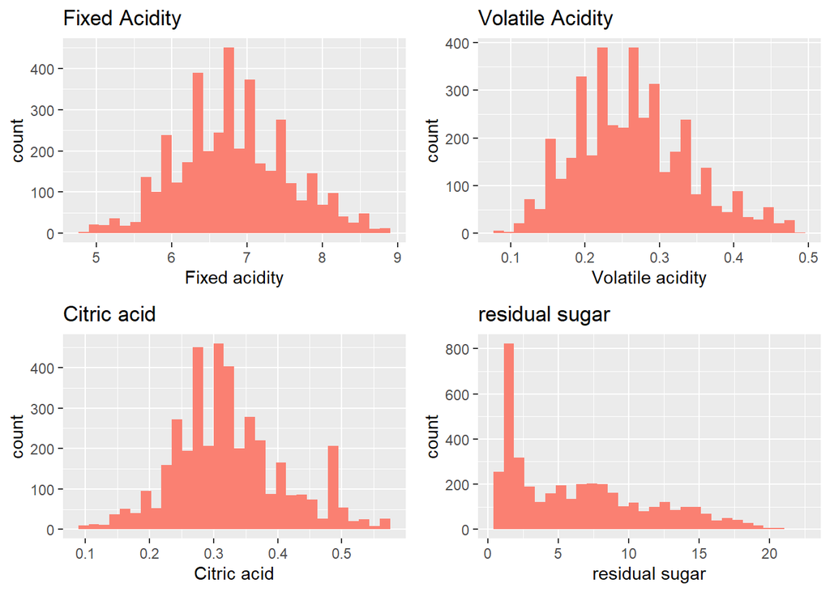

```r
p1 <- ggplot(df, aes(x=fixed.acidity)) + ggtitle("Fixed Acidity") +
  xlab("Fixed acidity") + geom_histogram(fill="salmon")
p2 <- ggplot(df, aes(x=volatile.acidity )) + ggtitle("Volatile Acidity") +
  xlab("Volatile acidity") + geom_histogram(fill="salmon")
p3 <- ggplot(df, aes(x=citric.acid)) + ggtitle("Citric acid") + xlab("Citric acid") +
  geom_histogram(fill="salmon")
p4 <- ggplot(df, aes(x=residual.sugar)) + ggtitle("residual sugar") +
  xlab("residual sugar") + geom_histogram(fill="salmon")
grid.arrange(p1, p2, p3, p4, ncol=2)
```

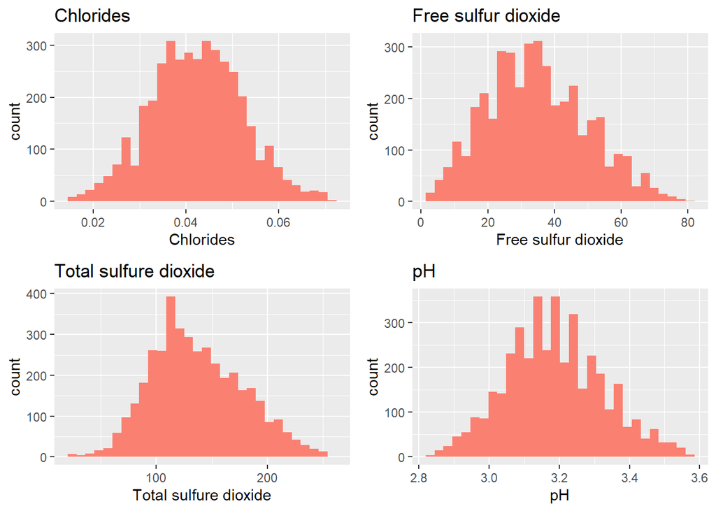

```r
p5 <- ggplot(df, aes(x=chlorides)) + ggtitle("Chlorides") +
  xlab("Chlorides") + geom_histogram(fill="salmon")
p6 <- ggplot(df, aes(x=free.sulfur.dioxide )) + ggtitle("Free sulfur dioxide")+
  xlab("Free sulfur dioxide") + geom_histogram(fill="salmon")
p7 <- ggplot(df, aes(x=total.sulfur.dioxide)) + ggtitle("Total sulfure dioxide") + xlab("Total sulfure dioxide") +
  geom_histogram(fill="salmon")
p8 <- ggplot(df, aes(x=pH)) + ggtitle("pH") +
  xlab("pH") + geom_histogram(fill="salmon")
grid.arrange(p5, p6, p7, p8, ncol=2)
```

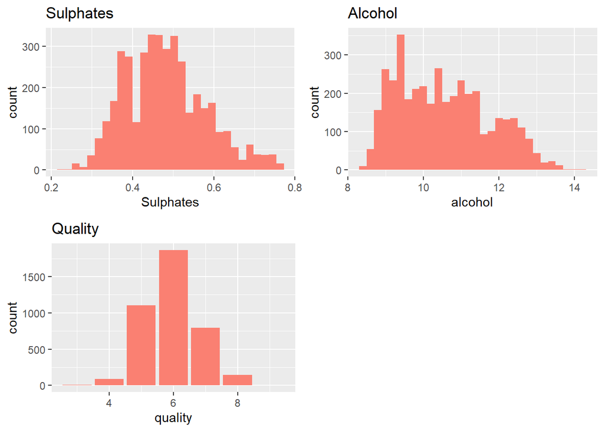

```r
p9 <- ggplot(df, aes(x=sulphates)) + ggtitle("Sulphates") +
  xlab("Sulphates") + geom_histogram(fill="salmon")
p10 <- ggplot(df, aes(x=alcohol )) + ggtitle("Alcohol")+
  xlab("alcohol") + geom_histogram(fill="salmon")
p11 <- ggplot(df, aes(x=quality)) + ggtitle("Quality") + xlab("quality") +
  geom_bar(fill="salmon")
grid.arrange(p9, p10, p11, ncol=2)
```

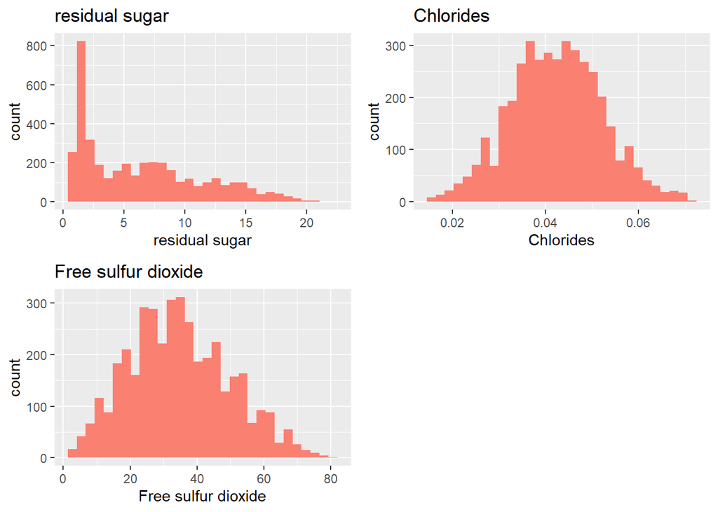

```r
grid.arrange(p4,p5,p6, ncol=2)
```

We notice that some variables are too skewed, I find it better to apply some transformations (there is a variety of transformations like log, sqrt, Box-Cox, Yeo-Johnon… so I will start by using log and sqrt to see which is better. Typically, we want that skewness < 1). What we could also do, and is more automatic is use “center=TRUE” later on when scaling, so R automatically takes care of skewness for us. So I will comment this code anyways to provide an alternative solution

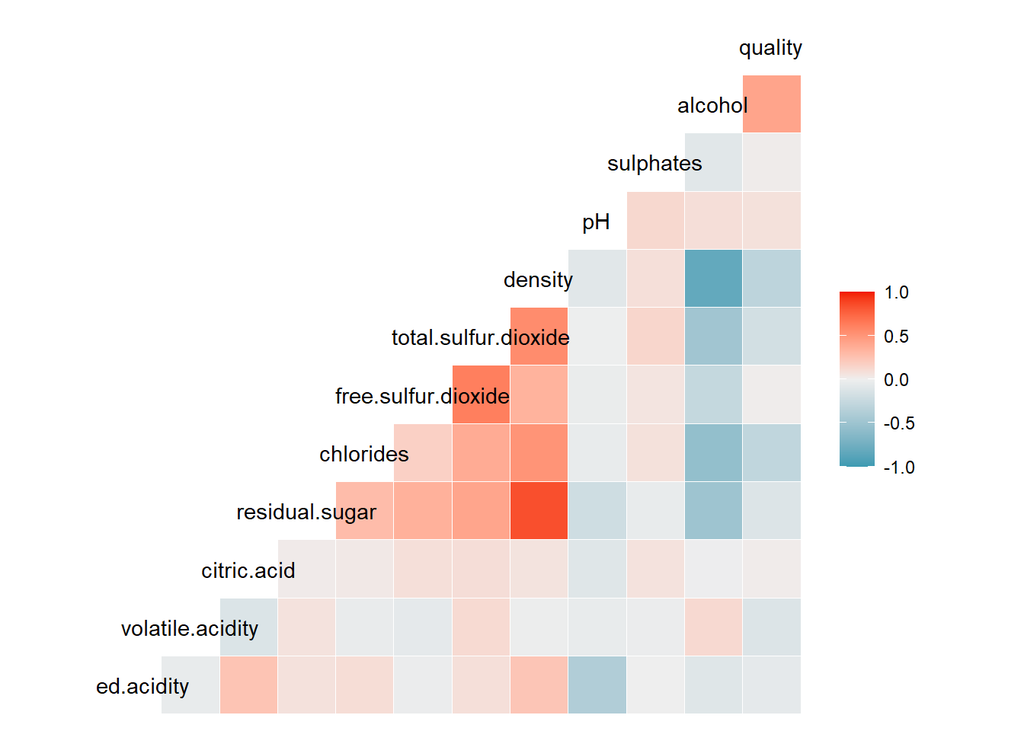

```r
# skewness(df$residual.sugar)
# df <- df %>% mutate(residual.sugar = log(residual.sugar))
# skewness(df$residual.sugar)
#
# skewness(df$chlorides)
# df <- df %>% mutate(chlorides = log(chlorides))
# skewness(df$chlorides)
#
# skewness(df$free.sulfur.dioxide)
# df<- df %>% mutate(free.sulfur.dioxide = sqrt(free.sulfur.dioxide))
# skewness(df$free.sulfur.dioxide)

#Check for correlation among variables
df %>% ggcorr()
```

Nothing really alarming except the high correlation between density and residual sugar. We will see later with stepwise selection and lasso, if this is taken care of.

I could spend more time analyzing the localization (Averages, mean, quantiles), and the variations but except the clearly skewed distributions of some of the variables, there is really nothing much to comment on from a unilateral perspective. With that being said, I think it is much more interesting to take a look at the bivariate analysis

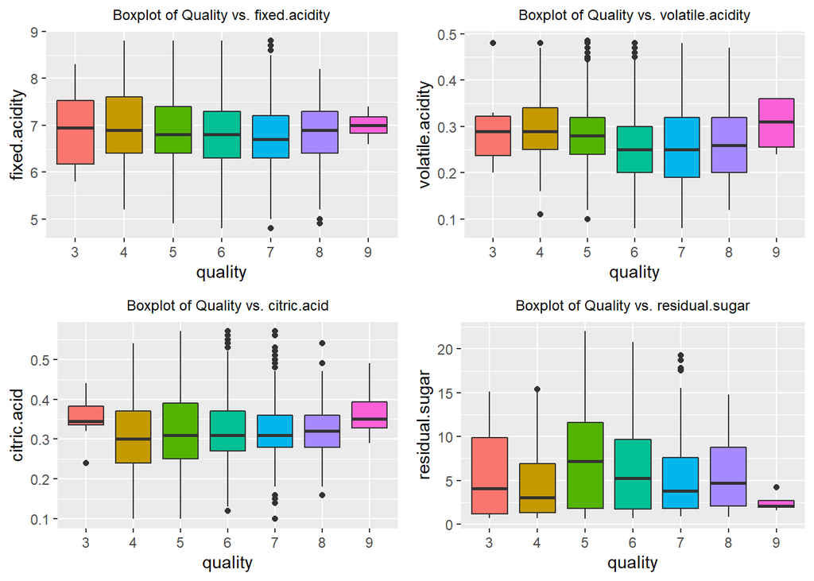

```r
#bivariate analysis:
g1 <- ggplot(df, aes(factor(quality), fixed.acidity, fill=factor(quality))) +
  geom_boxplot() +
  labs(x = "quality", y = "fixed.acidity", title = "Boxplot of Quality vs. fixed.acidity") +
  theme(legend.position = 'none', plot.title = element_text(size = 9, hjust=0.5))

g2 <- ggplot(df, aes(factor(quality), volatile.acidity, fill=factor(quality))) +
  geom_boxplot() +
  labs(x = "quality", y = "volatile.acidity", title = "Boxplot of Quality vs. volatile.acidity") +
  theme(legend.position = 'none', plot.title = element_text(size = 9, hjust=0.5))

g3 <- ggplot(df, aes(factor(quality), citric.acid, fill=factor(quality))) +
  geom_boxplot() +
  labs(x = "quality", y = "citric.acid", title = "Boxplot of Quality vs. citric.acid") +
  theme(legend.position = 'none', plot.title = element_text(size = 9, hjust=0.5))

g4 <- ggplot(df, aes(factor(quality), residual.sugar, fill=factor(quality))) +
  geom_boxplot() +
  labs(x = "quality", y = "residual.sugar", title = "Boxplot of Quality vs. residual.sugar") +
  theme(legend.position = 'none', plot.title = element_text(size = 9, hjust=0.5))
ggarrange(g1, g2, g3, g4, nrow = 2, ncol =2)
```

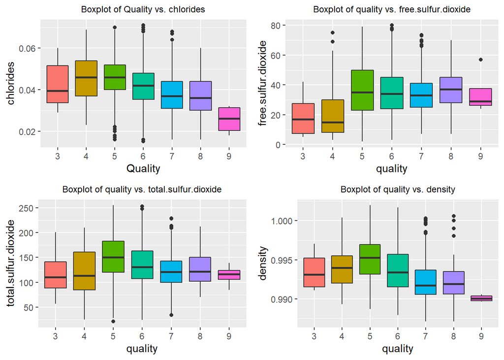

```r
g5 <- ggplot(df, aes(factor(quality), chlorides, fill=factor(quality))) +
  geom_boxplot() +
  labs(x = "Quality", y = "chlorides", title = "Boxplot of Quality vs. chlorides") +
  theme(legend.position = 'none', plot.title = element_text(size = 9, hjust=0.5))

g6 <- ggplot(df, aes(factor(quality), free.sulfur.dioxide, fill=factor(quality))) +
  geom_boxplot() +
  labs(x = "quality", y = "free.sulfur.dioxide", title = "Boxplot of quality vs. free.sulfur.dioxide") +
  theme(legend.position = 'none', plot.title = element_text(size = 9, hjust=0.5))

g7 <- ggplot(df, aes(factor(quality), total.sulfur.dioxide, fill=factor(quality))) +
  geom_boxplot() +
  labs(x = "quality", y = "total.sulfur.dioxide", title = "Boxplot of quality vs. total.sulfur.dioxide") +
  theme(legend.position = 'none', plot.title = element_text(size = 9, hjust=0.5))

g8 <- ggplot(df, aes(factor(quality), density, fill=factor(quality))) +
  geom_boxplot() +
  labs(x = "quality", y = "density", title = "Boxplot of quality vs. density") +
  theme(legend.position = 'none', plot.title = element_text(size = 9, hjust=0.5))
ggarrange(g5, g6, g7, g8, nrow = 2, ncol =2)
```

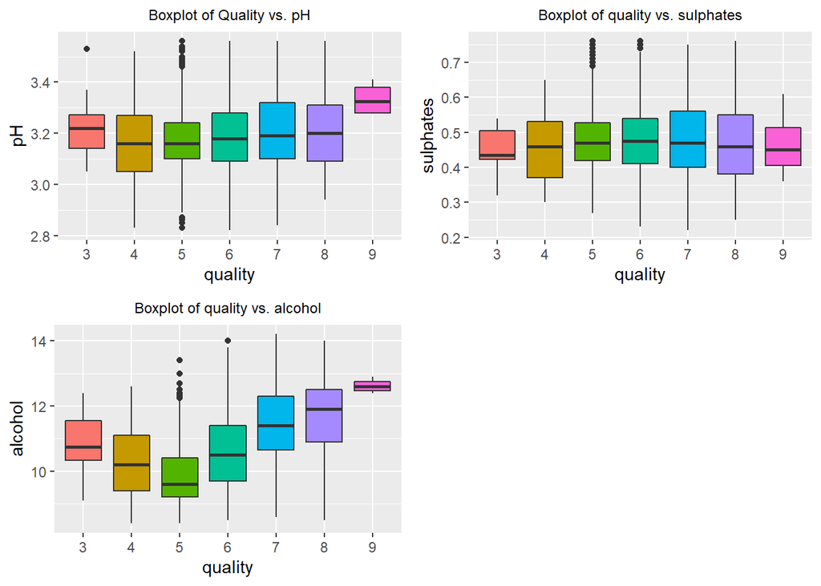

```r
g9 <- ggplot(df, aes(factor(quality), pH, fill=factor(quality))) +
  geom_boxplot() +
  labs(x = "quality", y = "pH", title = "Boxplot of Quality vs. pH") +
  theme(legend.position = 'none', plot.title = element_text(size = 9, hjust=0.5))

g10 <- ggplot(df, aes(factor(quality), sulphates, fill=factor(quality))) +
  geom_boxplot() +
  labs(x = "quality", y = "sulphates", title = "Boxplot of quality vs. sulphates") +
  theme(legend.position = 'none', plot.title = element_text(size = 9, hjust=0.5))

g11 <- ggplot(df, aes(factor(quality), alcohol, fill=factor(quality))) +
  geom_boxplot() +
  labs(x = "quality", y = "alcohol", title = "Boxplot of quality vs. alcohol") +
  theme(legend.position = 'none', plot.title = element_text(size = 9, hjust=0.5))
ggarrange(g9, g10, g11, nrow = 2, ncol =2)
```

——————–END OF DATA EXPLORATION + CLEANING

```r
#split data into train/test set
p=ncol(df)
train_index <- createDataPartition(df$quality, p = .9,
                                   list = FALSE,
                                   times = 1)
traintot <- df[train_index, ]
test <- df[-train_index, ]

#Here we directly put center = TRUE instead of using skewness, as mentioned above
trainScalenum <- traintot %>% select(-p) %>%  scale(center=TRUE, scale = TRUE)
```

```
## Note: Using an external vector in selections is ambiguous.
## i Use `all_of(p)` instead of `p` to silence this message.
## i See <https://tidyselect.r-lib.org/reference/faq-external-vector.html>.
```

```r
trainScale <- cbind(trainScalenum, quality=traintot[,p])
trainScale
testScalenum <- test %>% select(-p) %>% scale(., center=attr(trainScalenum, "scaled:center"),
                                                           scale=attr(trainScalenum, "scaled:scale"))
testScale <- cbind(testScalenum, quality=test[,p])

trainScale <- data.frame(trainScale)
testScale <- data.frame(testScale)


#Split train (already scaled) into train/validation set
train_index2 <- createDataPartition(trainScale$quality, p = .8,
                                   list = FALSE,
                                   times = 1)
trainScaled <- trainScale[train_index2, ]
validationScaled <- trainScale[-train_index2, ]



trainScaled <- data.frame(trainScaled)
validationScaled <- data.frame(validationScaled)
```

```r
set.seed(1)
#Analysis of some variables with respect to quality to get some interesting insights
#as requested by you and as I did in the midterm. Lower dimensional model
myfirstfit = lm(quality~alcohol*pH, data=trainScaled)
summary(myfirstfit)
```

```
##
## Call:
## lm(formula = quality ~ alcohol * pH, data = trainScaled)
##
## Residuals:
##     Min      1Q  Median      3Q     Max
## -3.5084 -0.5524 -0.0062  0.4556  2.7266
##
## Coefficients:
##             Estimate Std. Error t value Pr(>|t|)
## (Intercept)  5.94038    0.01443 411.551  < 2e-16 ***
## alcohol      0.37257    0.01449  25.714  < 2e-16 ***
## pH           0.03396    0.01428   2.378   0.0175 *
## alcohol:pH   0.06350    0.01461   4.346 1.43e-05 ***
## ---
## Signif. codes:  0 '***' 0.001 '**' 0.01 '*' 0.05 '.' 0.1 ' ' 1
##
## Residual standard error: 0.7732 on 2889 degrees of freedom
## Multiple R-squared:  0.1915, Adjusted R-squared:  0.1907
## F-statistic: 228.1 on 3 and 2889 DF,  p-value: < 2.2e-16
```

```r
#Function that will allow us to easily evaluate our models based on specific metrics. This will allow us to have a similar comparison at the end between the different models
myval = function(pred, actual,title= "") {
  rmse = sqrt(mean((pred - actual)^2))
  mae = mean(abs(pred - actual))
  par(mfrow = c(1,3), oma = c(0, 0, 3, 0))
  resid = pred - actual
  plot(resid)
  plot(jitter(actual, factor = 1),
       jitter(pred, factor = 0.5),
       pch = 4, asp = 1,
       xlab = "Truth", ylab = "Predicted")
  abline(0,1, lty = 2)
  hist(resid, breaks = 20, main = NULL)
  mtext(paste0(title, " predicted vs. actual using test set"), outer = TRUE)
  return(list(rmse = rmse,
              mae = mae
  ))
}
```

——–Step 2: Vanilla models

```r
#Real talk, start fitting models. The procedure that I will follow is first fit VANILLA models and optimize the best models I got (models with lower mae and rmse)
lm.fit = lm(quality~., data = trainScaled)
lm.pred = predict(lm.fit, validationScaled[,-p])
lm.myval = myval(lm.pred, validationScaled$quality, title = "linear model: predicted vs true"); unlist(lm.myval)
```

[output not shown]

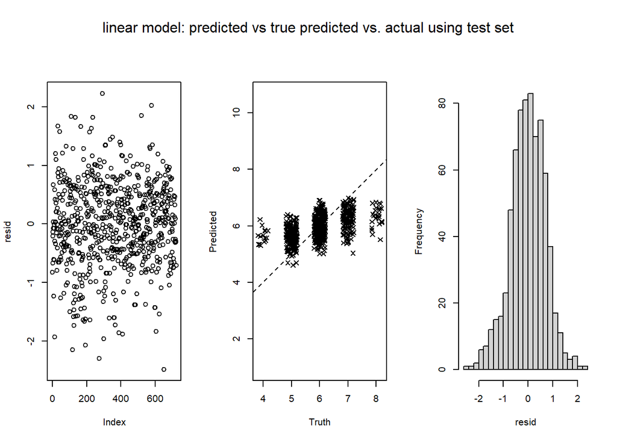

```r
#Difference between predicted and true quality is not too bad.



# variable selection using stepwise methods
lm_simple = lm(quality ~ ., data = trainScaled)
lm_step = step(lm_simple, ~ fixed.acidity + volatile.acidity +
                                      citric.acid + residual.sugar +  chlorides + free.sulfur.dioxide +
                                      total.sulfur.dioxide + density + pH + sulphates + alcohol,
                            direction = "both",trace = 0)
summary(lm_step)

lm_step_pred = predict(lm_step, validationScaled[,-p])
lm_step_myval = myval(lm_step_pred, validationScaled$quality, title="stepwise model: predicted vs true");unlist(lm_step_myval)
```

[output not shown]

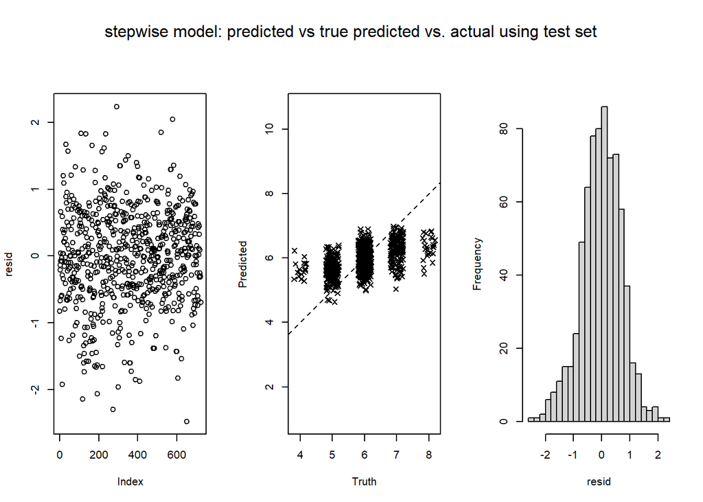

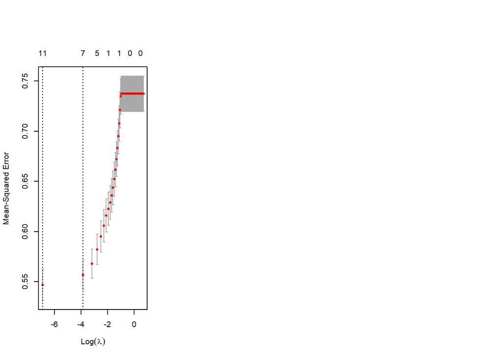

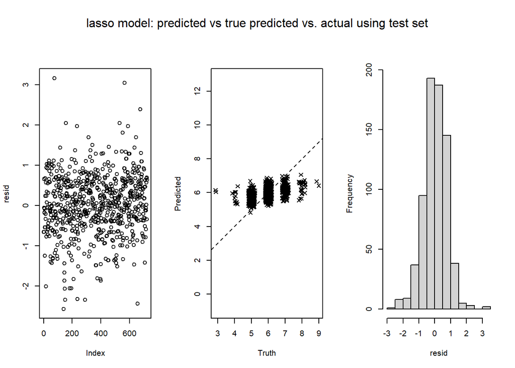

```r
#LASSO + Elastic net + Ridge
dat = traintot %>% as_tibble()
X <- model.matrix(quality~.-1, data = dat)
Y <- dat$quality

n <- nrow(dat)

#Let's resplit to satisy format of lasso
ntr <- round(n*0.8)
nte <- n-ntr
trIdx <- sample(1:n, size=ntr)
Xtr <- X[trIdx,]
Ytr <- Y[trIdx]
Xte <- X[-trIdx,]
Yte <- Y[-trIdx]
XtrS <- Xtr %>% scale()   # This standardizes Xtr
XteS <- Xte %>% scale(., center=attr(XtrS, "scaled:center"),
                            scale=attr(XtrS, "scaled:scale"))
#When standardizing the test (here validation actually) set, we make sure to use
#center of train set or else it will be catastrophic.

nlambdas <- 100
lambdas <- seq(0.001, 2, length.out = nlambdas)
nfolds <- 5

#Lasso model
Lasso.cv <- cv.glmnet(XtrS, Ytr, lambda=lambdas, alpha=1,
                      family="gaussian")
plot(Lasso.cv)


lambdaStar <- Lasso.cv$lambda.1se
lasso_pred = predict(Lasso.cv, XteS, s=lambdaStar)
lasso_myval = myval(lasso_pred, Yte, title="lasso model: predicted vs true"); unlist(lasso_myval)
```

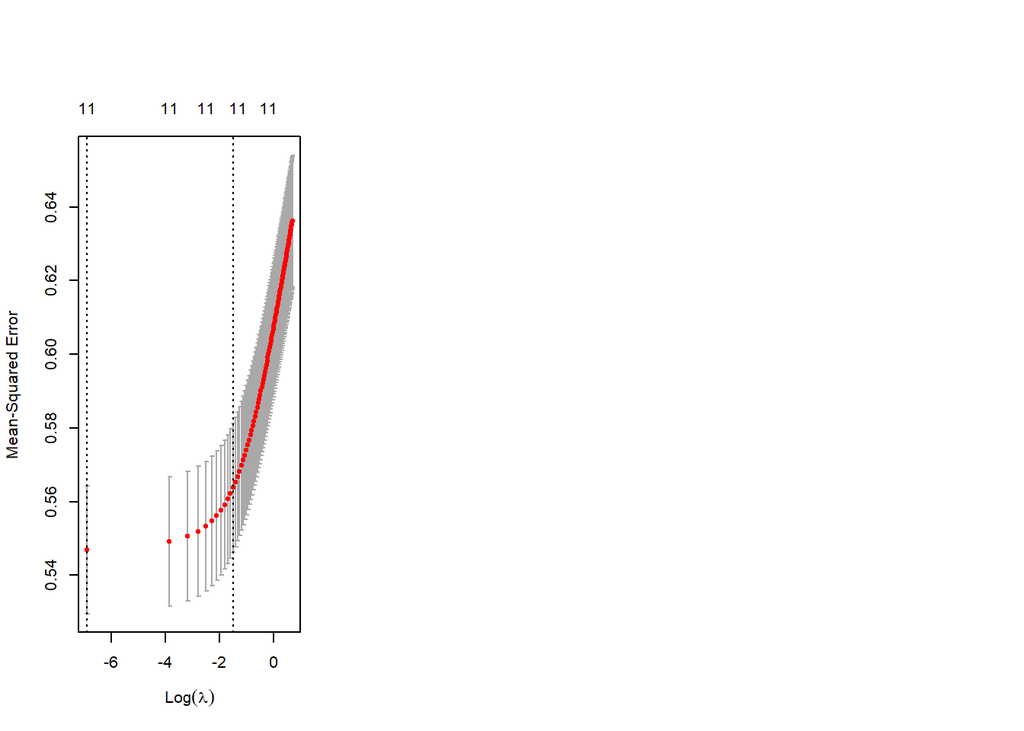

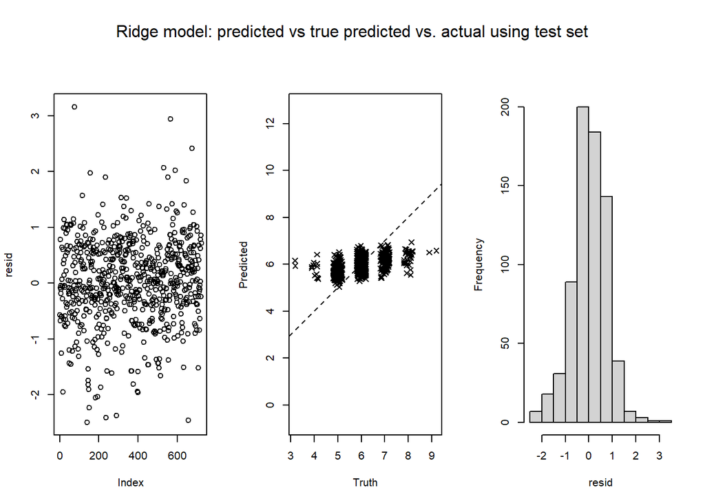

```r
#Ridge model
Ridge.cv <- cv.glmnet(XtrS, Ytr, lambda=lambdas, alpha=0,
                      family="gaussian")
plot(Ridge.cv)


lambdaStar <- Ridge.cv$lambda.1se
ridge_pred = predict(Ridge.cv, XteS, s=lambdaStar)
ridge_myval = myval(ridge_pred, Yte, title="Ridge model: predicted vs true"); unlist(ridge_myval)
```

```r
#Elastic net

unregister_dopar()

nalphas <- 20
alphas <- seq(0, 1, length.out=nalphas)
ctrl <- trainControl(method="cv", number=nfolds)
elastic.caret <- caret::train(XtrS, Ytr, method = "glmnet", trControl = ctrl,
                     tuneGrid = expand.grid(alpha = alphas,
                                            lambda = lambdas))
best_alpha = elastic.caret$bestTune$alpha
best_lambda = elastic.caret$bestTune$lambda

elastic_pred = predict(elastic.caret, XteS, s=best_lambda, a = best_alpha)
elastic_myval = myval(elastic_pred, Yte, title="elastic model: predicted vs actual"); unlist(elastic_myval)
```

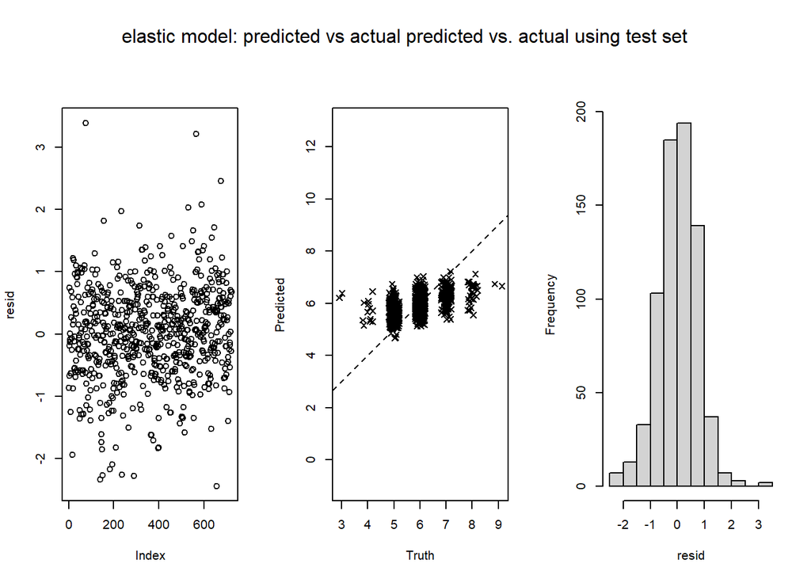

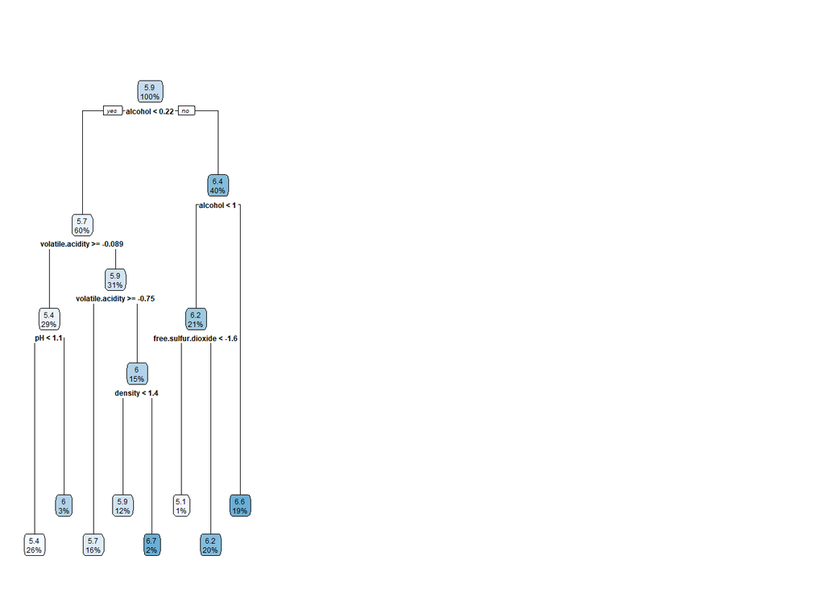

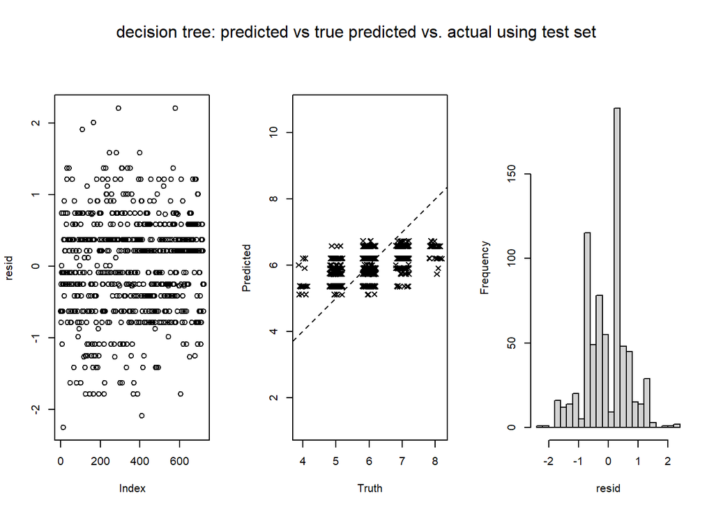

```r
#-------Moving on to tree-based algorithms----------

#Let's run a decision tree algorithm. Here I decided to use rpart instead of the
#method we saw in class, but tested them both and gave same results
dtree_mod = rpart(quality~., data=trainScaled)
rpart.plot(dtree_mod)
dtree_mod.pred = predict(dtree_mod, validationScaled[,-p])
dtree_mod.myval = myval(dtree_mod.pred, validationScaled$quality, title="decision tree: predicted vs true"); unlist(dtree_mod.myval)
```

```r
# RF model
rf_mod= randomForest(quality~., data=trainScaled, ntree=1000, mtry=3)
rf_mod_pred = predict(rf_mod, validationScaled[,-p])
rf_mod_myval = myval(rf_mod_pred, validationScaled$quality, title="random forest: predicted vs true"); unlist(rf_mod_myval)
```

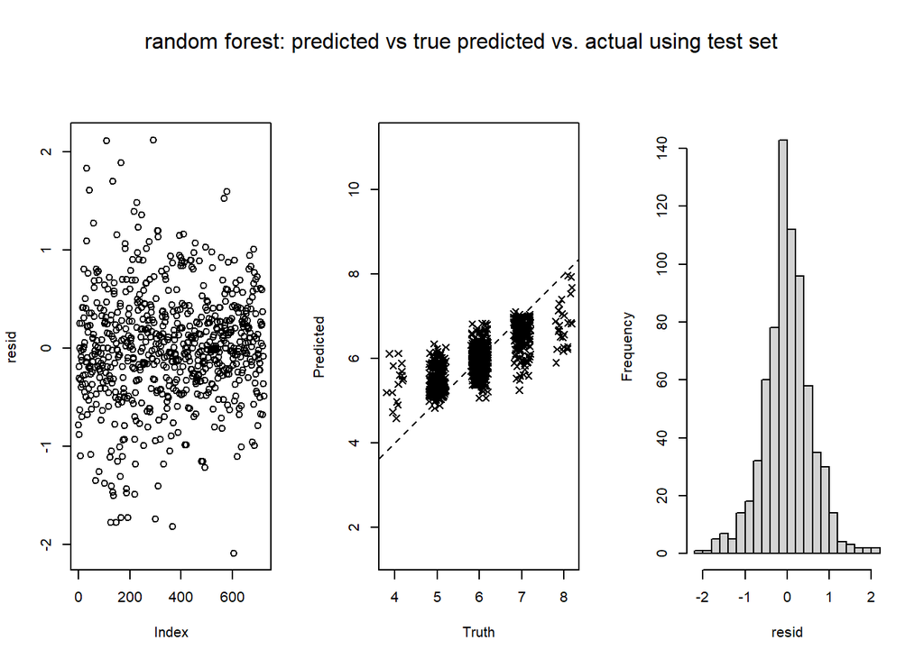

```r
#xgboost
fitControl = trainControl(
  method = "cv",
  number = 10,
  )

tune_grid =
  expand.grid(
    nrounds = c(50, 80),
    eta = c(0.03,0.01),
    max_depth=c(6, 5),
    subsample = c(0.75, 1),
    colsample_bytree = c(0.4, 0.6),
    min_child_weight = c(1, 3),
    gamma = c(0.05, 0.1)
  )
```

```r
#GAM model with smoothing splines
library(splines)
fit = smooth.spline(trainScaled$density, trainScaled$alcohol,cv=TRUE)
```

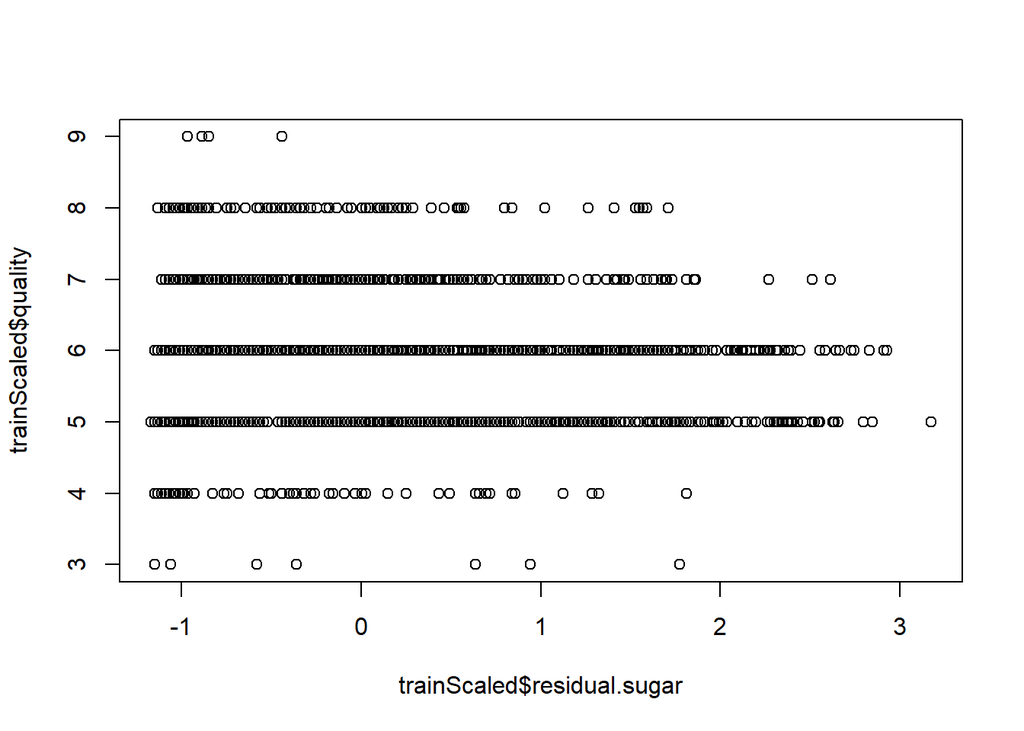

```r
plot(trainScaled$residual.sugar, trainScaled$quality)
```

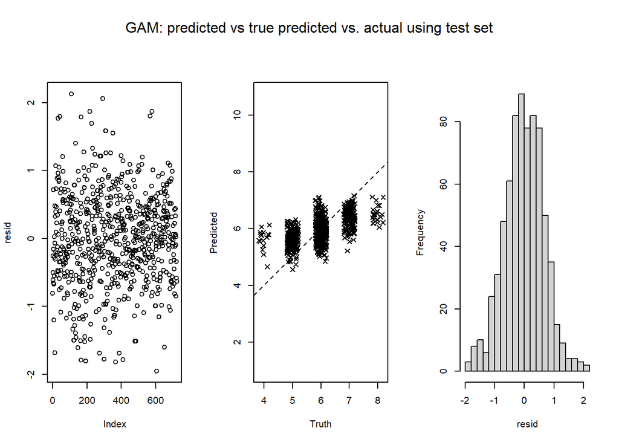

```r
# lines(fit,col="red",lwd=2)
#I found optimal degrees of freedom for each variable and applied it. We see improvement
#in results. I will not detail how I found optimal degrees of freedom for each variable
#but I can upon request
ga.model <- gam(quality ~ s(alcohol,12.23) + s(volatile.acidity,4) + s(sulphates,6.43) + s(chlorides,5.23) +
                  s(total.sulfur.dioxide,5.87) + s(free.sulfur.dioxide,8.5) +  s(citric.acid, 2) + s(pH,4.35) +
                  s(residual.sugar,23.16) + s(density,8) + s(fixed.acidity,4.3),
                data = trainScaled)
summary(ga.model)

gam_preds <- predict(ga.model, validationScaled[,-p])
gam_myval = myval(gam_preds, validationScaled$quality, title="GAM: predicted vs true"); unlist(gam_myval)
```

```r
#ASIDE: LM with top variables, just to see if there is improvement on full LM
lm0 = glm(quality ~ alcohol + density + chlorides + volatile.acidity + total.sulfur.dioxide, data = trainScaled)
lm.fit.reduced = lm(quality~ alcohol + density + chlorides + volatile.acidity + total.sulfur.dioxide, data = trainScaled)
summary(lm.fit)
lm.pred.reduced = predict(lm0, validationScaled[,-p])
lm_reduced_myval = myval(lm.pred.reduced, validationScaled$quality, "LM with best features: predicted vs true"); unlist(lm_reduced_myval)
```

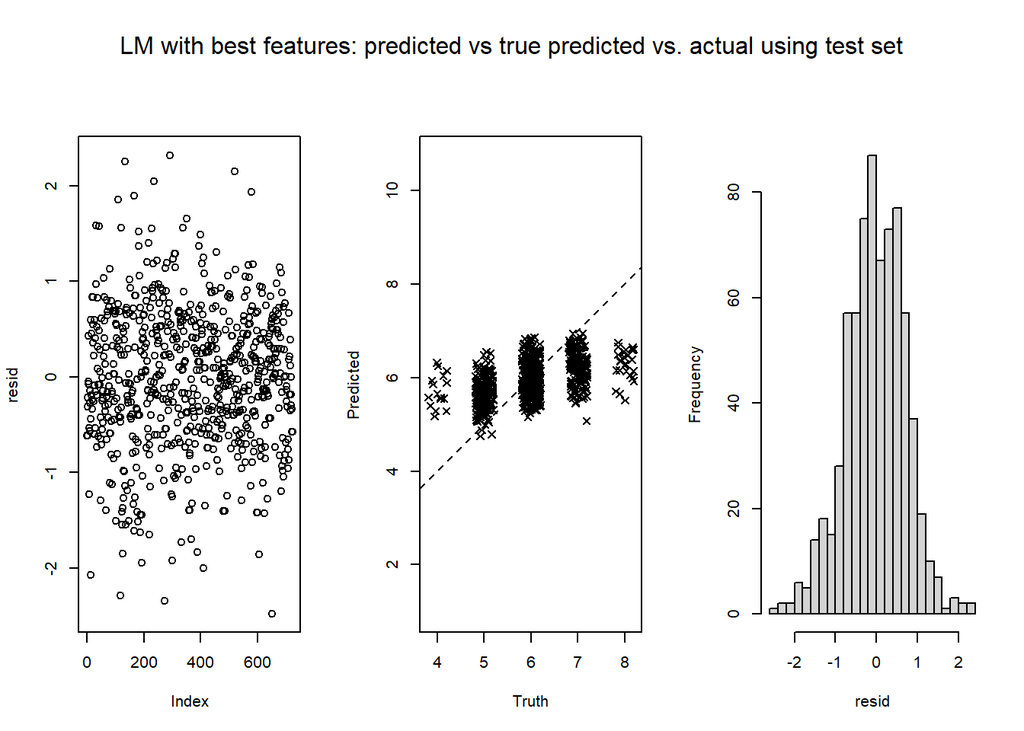

```r
knitr::kable(cbind(lm = unlist(lm.myval),
                   lm.interac = unlist(lm_step_myval),
                   lasso = unlist(lasso_myval),
                   ridge = unlist(ridge_myval),
                   elastic.net = unlist(elastic_myval),
                   rf = unlist(rf_mod_myval),
                   # rf.cv = unlist(cvrf_myval),
                   # lm.reduced = unlist(lm_reduced_myval),
                   regression.tree = unlist(dtree_mod.myval),
                   xgb = unlist(xg_myval),
                   # xgb_best = unlist(best.xgb.myval),
                   gam = unlist(gam_myval)) ,


             caption = "Models for regression: ")
```

Models for regression:

|  | lm | lm.interac | lasso | ridge | elastic.net | rf | regression.tree | xgb | gam |
| --- | --- | --- | --- | --- | --- | --- | --- | --- | --- |
| rmse | 0.7116473 | 0.7114052 | 0.7387967 | 0.7406007 | 0.7352616 | 0.5664087 | 0.7056379 | 0.8143711 | 0.6684557 |
| mae | 0.5565460 | 0.5561850 | 0.5693219 | 0.5681340 | 0.5650562 | 0.4169006 | 0.5742660 | 0.6400096 | 0.5283177 |

–Step 3: Optimizing best model found in 2.

```r
#Now that we found that RF is the best performing, I will further optimize it
#by using RF with CV
ct = trainControl(method = "repeatedcv", number = 10, repeats = 2)
grid_rf = expand.grid(.mtry = c(3, sqrt(p), p/3))

cvrf = train(quality~., data = trainScaled,
                method = 'rf',
                metric = "RMSE",
                trControl = ct,
                tuneGrid = grid_rf)
cvrf_pred = predict(cvrf, validationScaled[,-p])
cvrf_myval = myval(cvrf_pred, validationScaled$quality, title="rf with CV: predicted vs true"); unlist(cvrf_myval)
```

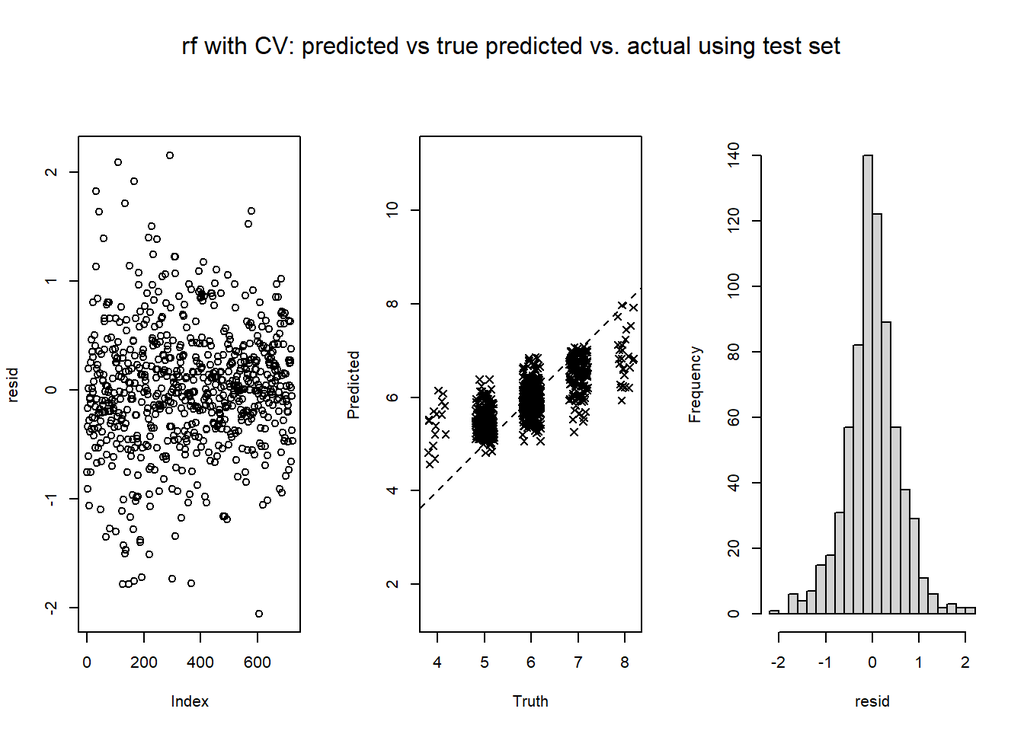

```
##      rmse       mae
## 0.5658744 0.4169541
```

We do not see significant improvement which means that our model was already optimal: no other hyperparameters to tune. Of course, if we increase number of repeats in ct, we may observe better results, but not significant enough.

Lastly, we see performance on real test set

```r
#fit best model (rf.cv) on TEST set and get predictions
cvrf.off.pred = predict(cvrf, testScale[,-p])
cvrf.off.myval = myval(cvrf.off.pred, testScale$quality, title="rf performance test set"); unlist(cvrf.off.myval)
```

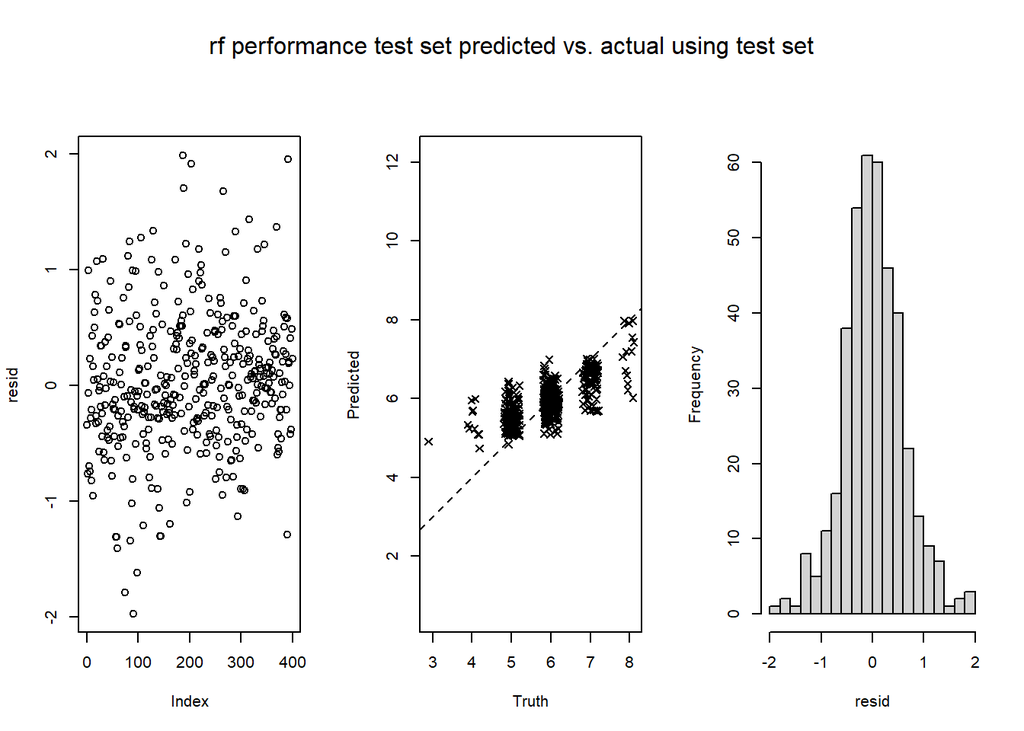

```
##      rmse       mae
## 0.5911567 0.4459407
```

```r
#Addtional optimization: this step has not led to significant improvement
#CAN BE IGNORED, but since I worked on it I decided to put it in
#I have decided to optimize xgboost because it has a lot of hyperparameters
#and I thought that I could do a good job at bettering the error rate.

#Finding best params for xgboost. I have to give full credit to a kaggle user
#who inspired me to follow this brilliant way of approaching this optimization
#problem. This honestly takes hours to run, so if you would like to uncomment it
#and run it, be my guest. Anyways, I will be presenting you with the results
#during my presentation. I must say, for the time I put into optimizing this model
#I was extremely deceived of the results because it slightly outperforms rf.cv in
#the "mae" metric but it still falls short in the "rmse" metric.

#YOU CAN IGNORE THE FOLLOWING SECTION IF YOU WOULD LIKE TO, WILL BE TALKING ABOUT
#IT IN PRESENTATION

#
# nrounds = 1000
# tune_grid <- expand.grid(
#   nrounds = seq(from = 200, to = nrounds, by = 50),
#   eta = c(0.025, 0.05, 0.1, 0.3),
#   max_depth = c(2, 3, 4, 5, 6),
#   gamma = 0,
#   colsample_bytree = 1,
#   min_child_weight = 1,
#   subsample = 1
# )
#
# tune_control <- caret::trainControl(
#   method = "cv",
#   number = 3,
#   verboseIter = FALSE
# )
#
# xgb_tune <- caret::train(
#   quality ~ ., data = trainScaled,
#   trControl = tune_control,
#   tuneGrid = tune_grid,
#   method = "xgbTree",
#   objective = "reg:squarederror",
#   eval_metric = "rmse",
#   verbose = TRUE
# )
#
# # helper function for the plots
# tuneplot <- function(x, probs = .90) {
#   ggplot(x) +
#     coord_cartesian(ylim = c(quantile(x$results$RMSE, probs = probs), min(x$results$RMSE))) +
#     theme_bw()
# }
#
# tuneplot(xgb_tune)
# xgb_tune$bestTune
#
#
# tune_grid2 <- expand.grid(
#   nrounds = seq(from = 50, to = nrounds, by = 50),
#   eta = xgb_tune$bestTune$eta,
#   max_depth = ifelse(xgb_tune$bestTune$max_depth == 6,
#                      c(xgb_tune$bestTune$max_depth:7),
#                      xgb_tune$bestTune$max_depth - 1:xgb_tune$bestTune$max_depth + 1),
#   gamma = 0,
#   colsample_bytree = 1,
#   min_child_weight = c(1, 2, 3),
#   subsample = 1
# )
#
# xgb_tune2 <- caret::train(
#   quality ~ ., data = trainScaled,
#   trControl = tune_control,
#   tuneGrid = tune_grid2,
#   method = "xgbTree",
#   objective = "reg:squarederror",
#   eval_metric = "rmse",
#   verbose = FALSE
# )
#
# tuneplot(xgb_tune2)
# xgb_tune2$bestTune
#
#
# tune_grid3 <- expand.grid(
#   nrounds = seq(from = 50, to = nrounds, by = 50),
#   eta = xgb_tune$bestTune$eta,
#   max_depth = xgb_tune2$bestTune$max_depth,
#   gamma = 0,
#   colsample_bytree = c(0.4, 0.6, 0.8, 1.0),
#   min_child_weight = xgb_tune2$bestTune$min_child_weight,
#   subsample = c(0.5, 0.75, 1.0)
# )
#
# xgb_tune3 <- caret::train(
#   quality ~ ., data = trainScaled,
#   trControl = tune_control,
#   tuneGrid = tune_grid3,
#   method = "xgbTree",
#   objective = "reg:squarederror",
#   eval_metric = "rmse",
#   verbose = FALSE
# )
#
# tuneplot(xgb_tune3, probs = .95)
#
#
# xgb_tune3$bestTune
#
# tune_grid4 <- expand.grid(
#   nrounds = seq(from = 50, to = nrounds, by = 50),
#   eta = xgb_tune$bestTune$eta,
#   max_depth = xgb_tune2$bestTune$max_depth,
#   gamma = c(0, 0.05, 0.1, 0.5, 0.7, 0.9, 1.0),
#   colsample_bytree = xgb_tune3$bestTune$colsample_bytree,
#   min_child_weight = xgb_tune2$bestTune$min_child_weight,
#   subsample = xgb_tune3$bestTune$subsample
# )
#
# xgb_tune4 <- caret::train(
#   quality ~ ., data = trainScaled,
#   trControl = tune_control,
#   tuneGrid = tune_grid4,
#   method = "xgbTree",
#   verbose = FALSE
# )
#
# tuneplot(xgb_tune4)
# xgb_tune4$bestTune
#
# tune_grid5 <- expand.grid(
#   nrounds = seq(from = 100, to = 10000, by = 100),
#   eta = c(0.01, 0.015, 0.025, 0.05, 0.1),
#   max_depth = xgb_tune2$bestTune$max_depth,
#   gamma = xgb_tune4$bestTune$gamma,
#   colsample_bytree = xgb_tune3$bestTune$colsample_bytree,
#   min_child_weight = xgb_tune2$bestTune$min_child_weight,
#   subsample = xgb_tune3$bestTune$subsample
# )
#
# xgb_tune5 <- caret::train(
#   quality ~ ., data = trainScaled,
#   trControl = tune_control,
#   tuneGrid = tune_grid5,
#   method = "xgbTree",
#   objective = "reg:squarederror",
#   eval_metric = "rmse",
#   verbose = FALSE
# )
#
# tuneplot(xgb_tune5)
# xgb_tune5$bestTune
#
#
# (final_grid <- expand.grid(
#   nrounds = xgb_tune5$bestTune$nrounds,
#   eta = xgb_tune5$bestTune$eta,
#   max_depth = xgb_tune5$bestTune$max_depth,
#   gamma = xgb_tune5$bestTune$gamma,
#   colsample_bytree = xgb_tune5$bestTune$colsample_bytree,
#   min_child_weight = xgb_tune5$bestTune$min_child_weight,
#   subsample = xgb_tune5$bestTune$subsample
# ))
#
# train_control <- caret::trainControl(
#   method = "none",
#   verboseIter = FALSE, # no training log
#   allowParallel = TRUE # FALSE for reproducible results
# )
#
# (xgb_model <- caret::train(
#   quality ~ ., data = trainScaled,
#   trControl = train_control,
#   tuneGrid = final_grid,
#   method = "xgbTree",
#   objective = "reg:squarederror",
#   eval_metric = "rmse",
#   verbose = FALSE
# ))
#
# best_xgb_mod = predict(xgb_model, validationScaled[,-p])
# best.xgb.myval = myval(best_xgb_mod, validationScaled$quality, title="Boosting: predicted vs actual"); unlist(best.xgb.myval)
#
```